# Lab 1

Carmen Canedo

May 24, 2020

# About

Below you will find an analysis of my path that was created using R statistical software. My code is available below, but my step-by-step process can be found on *[my GitHub page](https://github.com/carmen-canedo/stat-202-lab1)*.

# Necessary packages

In order to run the code below, the following packages must be installed and loaded on your computer.

```r
library(mdsr)
library(XML)
library(OpenStreetMap)
library(lubridate)
library(ggmap)
library(raster)
library(sp)
```

# Getting the data ready

Before conducting an analysis on my data, I found that it was necessary to narrow down the number of columns and rename some columns for clarity.

## Loading in data from .csv

Saving .csv file into a dataframe that can be easily manipulated.

```r
walking <- read.csv("lab-1.csv", header = TRUE)
```

## Cleaning data

### Getting rid of unnecessary columns

```r
walking <- walking %>%
  dplyr::select(-type, -desc, -name)
```

### Making column names simpler

```r
walking <- walking %>%
  rename(altitude = altitude..ft.) %>%
  rename(speed = speed..mph.) %>%
  rename(distance_mi = distance..mi.) %>%
  rename(distance_int_ft = distance_interval..ft.)
```

# Summary stats calculations

Summary statistics provide us with key information on the center and spread of our data; below, I calculate the minimum, first quartile, median, third quartile, max, mean, and standard deviation of all the variables in the data set.

```r
sum_latitude <- favstats( ~ latitude, data = walking)

sum_longitude <- favstats( ~ longitude, data = walking)

sum_altitude <- favstats( ~ altitude, data = walking)

sum_speed <- favstats( ~ speed, data = walking)

sum_distance_mi <- favstats( ~ distance_mi, data = walking)

sum_dist_int_ft <- favstats( ~ distance_int_ft, data = walking)
```

## Results

```r
sum_latitude
```

|  | min | Q1 | median | Q3 | max | mean | sd | n | missing |
| --- | --- | --- | --- | --- | --- | --- | --- | --- | --- |
|  | 36.18001 | 36.18029 | 36.1806 | 36.18091 | 36.18117 | 36.1806 | 0.0003514294 | 221 | 0 |

```r
sum_longitude
```

|  | min | Q1 | median | Q3 | max | mean | sd | n | missing |
| --- | --- | --- | --- | --- | --- | --- | --- | --- | --- |
|  | -86.74297 | -86.74294 | -86.7429 | -86.74286 | -86.74278 | -86.7429 | 4.645446e-05 | 221 | 0 |

```r
sum_altitude
```

|  | min | Q1 | median | Q3 | max | mean | sd | n | missing |
| --- | --- | --- | --- | --- | --- | --- | --- | --- | --- |
|  | 500.8 | 505.8 | 511.2 | 512.4 | 516.1 | 509.3181 | 4.041696 | 221 | 0 |

```r
sum_speed
```

|  | min | Q1 | median | Q3 | max | mean | sd | n | missing |
| --- | --- | --- | --- | --- | --- | --- | --- | --- | --- |
|  | 0 | 2.275 | 2.7 | 3.325 | 10 | 2.839545 | 1.226507 | 220 | 1 |

```r
sum_distance_mi
```

|  | min | Q1 | median | Q3 | max | mean | sd | n | missing |
| --- | --- | --- | --- | --- | --- | --- | --- | --- | --- |
|  | 0 | 0.047 | 0.09 | 0.137 | 0.181 | 0.09093213 | 0.05260591 | 221 | 0 |

```r
sum_dist_int_ft
```

|  | min | Q1 | median | Q3 | max | mean | sd | n | missing |
| --- | --- | --- | --- | --- | --- | --- | --- | --- | --- |
|  | 0 | 3.14 | 4.01 | 5.29 | 14.58 | 4.32362 | 1.937173 | 221 | 0 |

### Analysis

- The standard deviation is larger for latitude than it is for longitude.
- This tells us that the latitude moves farther from the mean than the longitude does. Thus, we can expect the path to go north to south.

# Creating latitude v. longitude scatter plot

Next, we are going to create a scatter plot of the longitude and latitude points that are colored based on my walking speed in miles per hour (mph). The speed uses a blue to red scale where the slower I walk, the more blue the point appears, and as my speed increases, the point becomes more red. Because I aimed to maintain a steady pace during my walk, most of the points are purple.

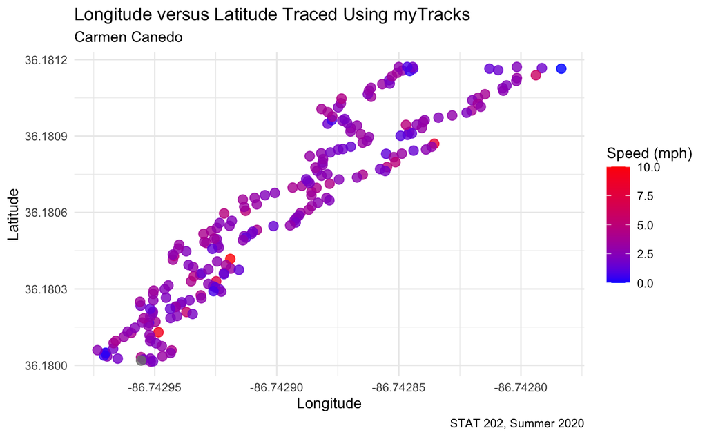

```r
lat_v_long <- walking %>%
  ggplot(aes(x = longitude, y = latitude)) +
  geom_point(alpha = 0.8, aes(color = speed), size = 3) +
  scale_color_gradient(low = "blue", high = "red") +
  theme_minimal() +
  labs(title = "Longitude versus Latitude Traced Using myTracks",
       subtitle = "Carmen Canedo",
       caption = "STAT 202, Summer 2020",
       x = "Longitude",
       y = "Latitude",
       color = "Speed (mph)")

lat_v_long
```

## Adding Line of Best Fit

In order to approximate the location of the sidewalk, we are going to add a line of best fit.

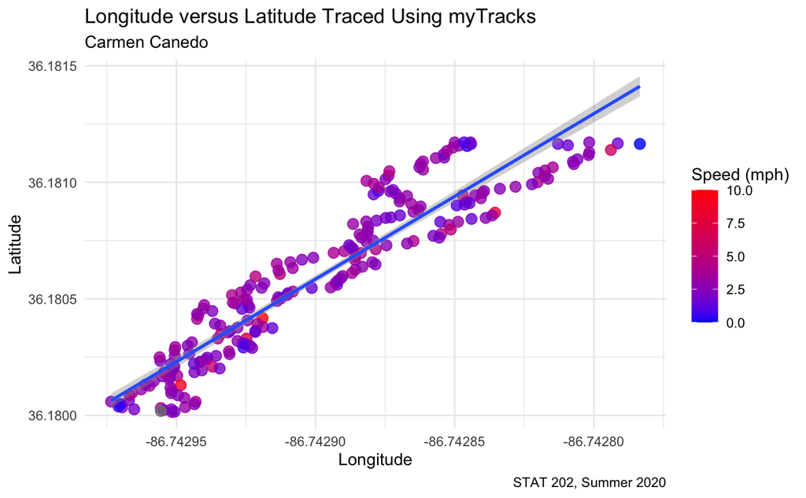

## Simple Linear Regression Results

Now, we will examine the linear regression more closely and determine the formula for the line of best fit.

```r
# Finding correlation coefficient
cor(walking$longitude, walking$latitude)
```

```
[1] 0.9379158
```

**Formula for line of best fit:** $latitude = 651.653 + 7.0954(longitude)$

`cor()` returns the correlation coefficient that will help us gauge whether our model actually represents the sidewalk well.

### Analysis

- The regression line is a good tool to estimate the path I traveled because it is able to predict the y-value given the change in the x-value.
- The correlation coefficient ranges from 0 to 1, and since our correlation value is 0.938, we can ascertain that our trend line accurately portrays the location of the sidewalk.

# Mapping the route

The exercises I referenced to create my own map can be found by clicking *[here](https://rpubs.com/ials2un/gpx1)*.

## Getting the data

In order to ensure that all the values work when mapped, this equation places the vectors correctly.

```r
# Function to shift vectors
shift_vec <- function(vector, shift) {
  if (length(vec) <= abs(shift)) {
    rep(NA, length(vec))
  } else {
    if (shift >= 0) {
      c(rep(NA, shift), vec[1:(length(vec) - shift)])
    } else {
      c(vec[(abs(shift) + 1):length(vec)])
    }
  }
}
```

## Reading in GPX file

Next we read in the GPX file itself instead of using the .csv file from above.

```r
# Limits to 10 digits
options(digits = 10)

# Parsing the GPX file
parsed_file <- htmlTreeParse(file = "lab-1-raw-data.gpx",
                             error = function(...) {},
                             useInternalNodes = TRUE)

# Get all times and coordinates via the respective xpath
times <- xpathSApply(parsed_file, path = "//trkpt/time", xmlValue)
coords <- xpathSApply(parsed_file, path = "//trkpt", xmlAttrs)

# Extract latitude and longitude from the coordinates
lats <- as.numeric(coords["lat",])
lons <- as.numeric(coords["lon",])
```

## Putting values into a dataframe

This allows us to have all of individual data points from the GPX file in one place, ready to be placed onto a map.

```r
geodf <- data.frame(lat = lats, lon = lons, time = times)
```

## Querying map background

I am using my Google API to access the static map used below. It is centered on the street where I walked, and I zoomed in so that my path will be visible.

```r
street <- get_map(location = "409 N 15th St., Lockeland Springs, Nashville, Tennessee",
                  zoom = 19,
                  maptype = "roadmap")
```

## Finished product

Finally, we can put all the data together and plot the points onto the map using the `ggmap` package.

```r
# Plotting points
path <- ggmap(street) +
  geom_point(data = geodf,
             aes(x = lon, y = lat),
             size = 1,
             alpha = 0.7,
             color = "red")

# Adding details
path <- path +
  labs(x = "Longitude",
       y = "Latitude",
       title = "Walking Path Plotted using myTracks",
       subtitle = "Carmen Canedo",
       caption = "STAT 202, Summer 2020")

# Printing map
path
```

[output not shown]

# Summary

This lab allowed me to apply statistical skills in a real life setting. I enjoy using R and Python, and though I have experience with them in other settings, it was really informative to use them to make statistical calculations. The biggest thing I learned was how to produce static maps using my very own Google API!